# Practical Machine Learning - Course Project

## Aim of the Project

The aim of the project is to build a machine learning model from the sample data that is attempting to most accurately predict the manner in which the exercise was performed by the data collected via quantified Self devices. This is a classification problem into discrete categories, which in the training data are located in the ‘classe’ variable.

## initial settings

```r
echo = TRUE  # visible code chunks
options(scipen = 1)  # Turn off scientific notations for numbers
set.seed(76543)
```

## Include Libraries

```r
library(rattle)
library(caret)
library(rpart)
```

```r
library(rpart.plot)
library(randomForest)
```

## Download the training data

```r
trainUrl <-"https://d396qusza40orc.cloudfront.net/predmachlearn/pml-training.csv"
testUrl <- "https://d396qusza40orc.cloudfront.net/predmachlearn/pml-testing.csv"
trainFile <- "./data/data-train.csv"
testFile  <- "./data/data-test.csv"
if (!file.exists("./data")) {
  dir.create("./data")
}
if (!file.exists(trainFile)) {
  download.file(trainUrl, destfile = trainFile, method = "curl")
}
if (!file.exists(testFile)) {
  download.file(testUrl, destfile = testFile, method = "curl")
}
rm(trainUrl)
rm(testUrl)
```

## Load data

```r
trainRaw <- read.csv(trainFile)
testRaw <- read.csv(testFile)
dim(trainRaw)
```

```
## [1] 19622   160
```

```r
dim(testRaw)
```

```
## [1]  20 160
```

```r
rm(trainFile)
rm(testFile)
```

## Clean data

1. Remove the columns where variance is near zero.

```r
NZV <- nearZeroVar(trainRaw, saveMetrics = TRUE)
head(NZV, 20)
```

```
##                        freqRatio percentUnique zeroVar   nzv
## X                       1.000000  100.00000000   FALSE FALSE
## user_name               1.100679    0.03057792   FALSE FALSE
## raw_timestamp_part_1    1.000000    4.26562022   FALSE FALSE
## raw_timestamp_part_2    1.000000   85.53154622   FALSE FALSE
## cvtd_timestamp          1.000668    0.10192641   FALSE FALSE
## new_window             47.330049    0.01019264   FALSE  TRUE
## num_window              1.000000    4.37264295   FALSE FALSE
## roll_belt               1.101904    6.77810621   FALSE FALSE
## pitch_belt              1.036082    9.37722964   FALSE FALSE
## yaw_belt                1.058480    9.97349913   FALSE FALSE
## total_accel_belt        1.063160    0.14779329   FALSE FALSE
## kurtosis_roll_belt   1921.600000    2.02323922   FALSE  TRUE
## kurtosis_picth_belt   600.500000    1.61553358   FALSE  TRUE
## kurtosis_yaw_belt      47.330049    0.01019264   FALSE  TRUE
## skewness_roll_belt   2135.111111    2.01304658   FALSE  TRUE
## skewness_roll_belt.1  600.500000    1.72255631   FALSE  TRUE
## skewness_yaw_belt      47.330049    0.01019264   FALSE  TRUE
## max_roll_belt           1.000000    0.99378249   FALSE FALSE
## max_picth_belt          1.538462    0.11211905   FALSE FALSE
## max_yaw_belt          640.533333    0.34654979   FALSE  TRUE
```

```r
training01 <- trainRaw[, !NZV$nzv]
testing01 <- testRaw[, !NZV$nzv]
dim(training01)
```

```
## [1] 19622   100
```

```r
dim(testing01)
```

```
## [1]  20 100
```

```r
rm(trainRaw)
rm(testRaw)
rm(NZV)
```

2. Remove also specific dimensional variables that may not be pertinent to the prediction model.

```r
regex <- grepl("^X|timestamp|user_name", names(training01))
training <- training01[, !regex]
testing <- testing01[, !regex]
rm(regex)
rm(training01)
rm(testing01)
```

3. Remove final NA’s

```r
cond <- (colSums(is.na(training)) == 0)
training <- training[, cond]
testing <- testing[, cond]
rm(cond)
dim(training)
```

```
## [1] 19622    54
```

```r
dim(testing)
```

```
## [1] 20 54
```

Now, the cleaned training data set contains 19622 observations and 54 variables, while the testing data set contains 20 observations and 54 variables.

## Splitting Dataset

```r
index <- createDataPartition(training$classe, p = 0.70, list = FALSE)
validation <- training[-index, ]
training <- training[index, ]
rm(index)
```

## Modelling

1. Decision Tree

We fit a predictive model for activity recognition using Decision Tree algorithm.

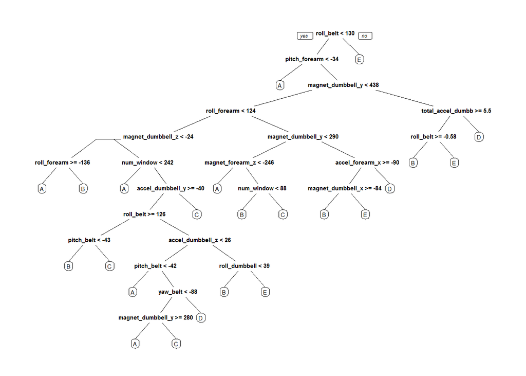

```r
modelTree <- rpart(classe ~ ., data = training, method = "class")
prp(modelTree)
```

Now, we estimate the performance of the model on the validation data set.

```r
predictTree <- predict(modelTree, validation, type = "class")
confusionMatrix(validation$classe, predictTree)
```

```
## Confusion Matrix and Statistics
##
##           Reference
## Prediction    A    B    C    D    E
##          A 1552   57   26   21   18
##          B  214  643  120   71   91
##          C   61   36  830   46   53
##          D  112   87  137  521  107
##          E   48   90   85   54  805
##
## Overall Statistics
##
##                Accuracy : 0.7393
##                  95% CI : (0.7279, 0.7505)
##     No Information Rate : 0.3376
##     P-Value [Acc > NIR] : < 2.2e-16
##
##                   Kappa : 0.668
##  Mcnemar's Test P-Value : < 2.2e-16
##
## Statistics by Class:
##
##                      Class: A Class: B Class: C Class: D Class: E
## Sensitivity            0.7811   0.7043   0.6928  0.73072   0.7495
## Specificity            0.9687   0.9002   0.9582  0.91435   0.9424
## Pos Pred Value         0.9271   0.5645   0.8090  0.54046   0.7440
## Neg Pred Value         0.8967   0.9431   0.9243  0.96098   0.9440
## Prevalence             0.3376   0.1551   0.2036  0.12116   0.1825
## Detection Rate         0.2637   0.1093   0.1410  0.08853   0.1368
## Detection Prevalence   0.2845   0.1935   0.1743  0.16381   0.1839
## Balanced Accuracy      0.8749   0.8023   0.8255  0.82253   0.8460
```

```r
accuracy <- postResample(predictTree, validation$classe)
ose <- 1 - as.numeric(confusionMatrix(validation$classe, predictTree)$overall[1])
rm(predictTree)
rm(modelTree)
```

2. Boosting Algorithm

```r
boostFit <- train(classe ~ ., method = "gbm", data = training, verbose = F, trControl = trainControl(method = "cv", number = 10))
boostFit
```

```
## Stochastic Gradient Boosting
##
## 13737 samples
##    53 predictor
##     5 classes: 'A', 'B', 'C', 'D', 'E'
##
## No pre-processing
## Resampling: Cross-Validated (10 fold)
## Summary of sample sizes: 12363, 12364, 12362, 12363, 12365, 12363, ...
## Resampling results across tuning parameters:
##
##   interaction.depth  n.trees  Accuracy   Kappa
##   1                   50      0.7577334  0.6926924
##   1                  100      0.8304596  0.7853493
##   1                  150      0.8687485  0.8338714
##   2                   50      0.8842580  0.8534516
##   2                  100      0.9403093  0.9244718
##   2                  150      0.9633858  0.9536713
##   3                   50      0.9321565  0.9141195
##   3                  100      0.9705910  0.9627870
##   3                  150      0.9879165  0.9847155
##
## Tuning parameter 'shrinkage' was held constant at a value of 0.1
##
## Tuning parameter 'n.minobsinnode' was held constant at a value of 10
## Accuracy was used to select the optimal model using  the largest value.
## The final values used for the model were n.trees = 150,
##  interaction.depth = 3, shrinkage = 0.1 and n.minobsinnode = 10.
```

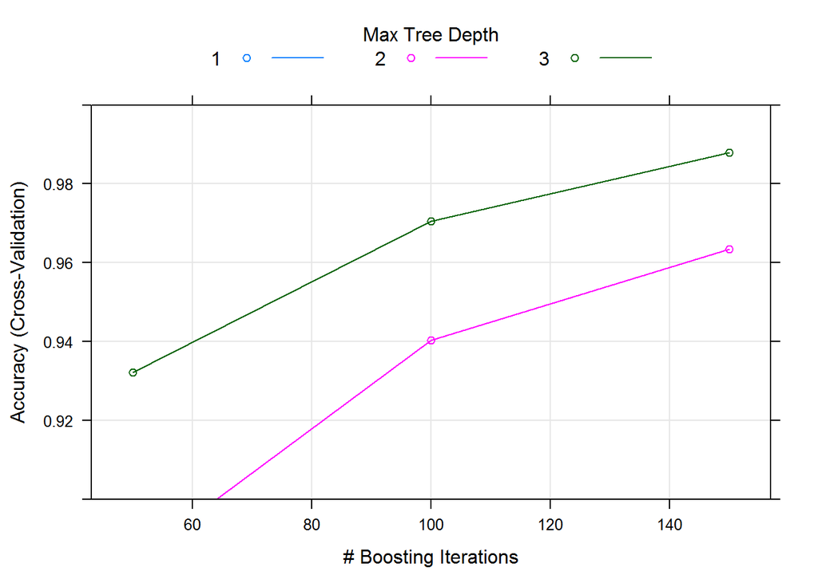

```r
plot(boostFit, ylim = c(0.9, 1))
```

The Estimated Accuracy of the Model is 98.79165%

3. Random Forest

Random Forest algorithm, 5 Cross Validation will be used.

```r
modelRF <- train(classe ~ ., data = training, method = "rf", trControl = trainControl(method = "cv", 5), ntree = 250)
modelRF
```

```
## Random Forest
##
## 13737 samples
##    53 predictor
##     5 classes: 'A', 'B', 'C', 'D', 'E'
##
## No pre-processing
## Resampling: Cross-Validated (5 fold)
## Summary of sample sizes: 10989, 10988, 10991, 10990, 10990
## Resampling results across tuning parameters:
##
##   mtry  Accuracy   Kappa
##    2    0.9927204  0.9907913
##   27    0.9964331  0.9954881
##   53    0.9930117  0.9911601
##
## Accuracy was used to select the optimal model using  the largest value.
## The final value used for the model was mtry = 27.
```

Now, we estimate the performance of the model on the validation data set.

```r
predictRF <- predict(modelRF, validation)
confusionMatrix(validation$classe, predictRF)
```

```
## Confusion Matrix and Statistics
##
##           Reference
## Prediction    A    B    C    D    E
##          A 1673    1    0    0    0
##          B    6 1129    4    0    0
##          C    0    0 1026    0    0
##          D    0    0    6  958    0
##          E    0    0    0    0 1082
##
## Overall Statistics
##
##                Accuracy : 0.9971
##                  95% CI : (0.9954, 0.9983)
##     No Information Rate : 0.2853
##     P-Value [Acc > NIR] : < 2.2e-16
##
##                   Kappa : 0.9963
##  Mcnemar's Test P-Value : NA
##
## Statistics by Class:
##
##                      Class: A Class: B Class: C Class: D Class: E
## Sensitivity            0.9964   0.9991   0.9903   1.0000   1.0000
## Specificity            0.9998   0.9979   1.0000   0.9988   1.0000
## Pos Pred Value         0.9994   0.9912   1.0000   0.9938   1.0000
## Neg Pred Value         0.9986   0.9998   0.9979   1.0000   1.0000
## Prevalence             0.2853   0.1920   0.1760   0.1628   0.1839
## Detection Rate         0.2843   0.1918   0.1743   0.1628   0.1839
## Detection Prevalence   0.2845   0.1935   0.1743   0.1638   0.1839
## Balanced Accuracy      0.9981   0.9985   0.9952   0.9994   1.0000
```

```r
accuracy <- postResample(predictRF, validation$classe)
ose <- 1 - as.numeric(confusionMatrix(validation$classe, predictRF)$overall[1])
rm(predictRF)
```

```r
rm(accuracy)
rm(ose)
predict(modelRF, testing[, -length(names(testing))])
```

```
##  [1] B A B A A E D B A A B C B A E E A B B B
## Levels: A B C D E
```

# Conclusion

The decition tree has an Accuracy of 74%. Boosting model and random forrest are on same scale and the latter is quite better with accuracy of 99%. Random forest will be used for predicting the test set.

## Project submission files

```r
pml_write_files = function(x){
  n = length(x)
  for(i in 1:n){
    filename = paste0("./Assignment_Solutions/problem_id_",i,".txt")
    write.table(x[i], file = filename, quote = FALSE, row.names = FALSE, col.names = FALSE)
  }
}
```

## Generate Data for Submitting

```r
pml_write_files(predict(modelRF, testing[, -length(names(testing))]))
rm(modelRF)
rm(training)
rm(testing)
rm(validation)
rm(pml_write_files)
```